# Ontario’s Path to Carbon Neutrality by 2050

## Problem Statement

While Canada maintains a robust inventory of greenhouse gas (GHG) emissions, significant ambiguity remains around how individual provinces — particularly Ontario — align with the federal objective of reaching carbon neutrality by 2050.

This project narrows its focus exclusively to Ontario to explore the province’s emission patterns, evaluate its alignment with national goals, and identify potential interventions.

## Objectives

- **Analyze Ontario’s Emissions Profile**  
  Assess historical GHG emissions in Ontario, disaggregated by sector where possible, to uncover key contributors and long-term trends.
- **Compare Against Federal Trajectory**  
  Examine whether Ontario’s current path supports or deviates from Canada’s carbon neutrality commitment.
- **Identify Gaps and Leverage Points**  
  Highlight areas where Ontario’s policy, industry, or infrastructure could adapt to accelerate emission reductions.

## Why This Matters

Ontario plays a central role in Canada’s economic and environmental landscape. Its success or failure in decarbonization efforts will significantly influence national outcomes. By isolating Ontario’s performance, this analysis provides a focused, data-driven foundation for:

- Provincial policymakers
- Sustainability professionals
- Strategic planners in energy and industry

## Phase 1: Data ingestion and Cleaning

### Data Ingestion

- Load the GHG emissions dataset into Jupyter notebook using `pandas`.
- Collect and tabularize data specifically related to Ontario's provincial emission targets.

### Data Cleaning

- Handle missing values and remove duplicates.
- Ensure consistent formatting for:
  - Dates (standard formats)
  - Numeric values (emission units, precision)

### Data Standardization

- Align schemas and formats across both datasets.
- Prepare data for seamless merging and comparative analysis.

## Explanation For Data Preparation: Ingesting and Cleaning Ontario GHG Emissions

To ensure high-quality analysis, I performed the following preprocessing steps:

- Loaded two datasets:
  - Greenhouse Gas (GHG) facility-level emissions
  - Provincial emission reduction targets
- Filtered and cleaned the GHG dataset by:
  - Dropping administrative and metadata columns not relevant to emissions
  - Renaming bilingual column headers to clear English labels
  - Removing raw gas columns in favor of their standardized CO₂-equivalent values
  - Addressing missing data using logic-based imputation (e.g., facility names)

**Click to view full data ingestion and cleaning code**

```
# ------------------------------------------------------------
# IMPORT LIBRARIES
# ------------------------------------------------------------
import pandas as pd
import matplotlib.pyplot as plt
import numpy as np
import seaborn as sns

# ------------------------------------------------------------
# DATASET 1: GHG Emissions Data
# ------------------------------------------------------------

# Setting
pd.set_option('display.float_format', '{:.4f}'.format)

# Load Dataset 1 (GHG Emissions)
emission_df = pd.read_csv("GHGEmissions.csv")

# Drop columns that are irrelevant for Ontario emissions analysis
columns_to_drop = [
    'GHGRP ID No. / No d\'identification du PDGES',
    'Facility Location / Emplacement de l\'installation',
    'Facility City or District or Municipality / Ville ou District ou Municipalité de l\'installation',
    'Latitude', 'Longitude',
    'Facility Postal Code / Code postal de l\'installation',
    'Facility NPRI ID / Numéro d\'identification de l\'INRP',
    'Facility NAICS Code / Code SCIAN de l\'installation',
    'French Facility NAICS Code Description / Description du code SCIAN de l\'installation en français',
    'Reporting Company Legal Name / Dénomination sociale de la société déclarante',
    'Reporting Company Business Number / Numéro d\'entreprise de la société déclarante',
    'DUNS Number / Numéro DUNS',
    'Public Contact Name / Nom du responsable des renseignements au public',
    'Public Contact Position / Poste ou Titre du responsable des renseignements au public',
    'Public Contact Telephone / Numéro de téléphone du responsable des renseignements au public',
    'Public Contact Extension / Poste téléphonique du responsable des renseignements au public',
    'Public Contact Email / Adresse électronique du responsable des renseignements au public',
    'Public Contact Mailing Address / Adresse postale du responsable des renseignements au public',
    'Public Contact City or District or Municipality / Ville ou District ou Municipalité du responsable des renseignements au public',
    'Public Contact Province or Territory / Province ou Territoire du responsable des renseignements au public',
    'Public Contact Postal Code / Code postal du responsable des renseignement au public',
    'GHGRP Quantification Requirements / Exigences de quantification du PDGES',
    'Emission Factors / Coefficients d\'émission',
    'Engineering Estimates / Estimations techniques',
    'Mass Balance / Bilan massique',
    'Monitoring or Direct Measurement / Surveillance ou mesure directe'
]
emission_df.drop(columns=[col for col in columns_to_drop if col in emission_df.columns], inplace=True)

# Rename bilingual columns to English-only for cleaner access
columns_rename_map = {
    "Reference Year / Année de référence": "Reference Year",
    "Facility Name / Nom de l'installation": "Facility Name",
    "Facility City or District or Municipality / Ville ou District ou Municipalité de l'installation": "Facility City",
    "Facility Province or Territory / Province ou territoire de l'installation": "Facility Province",
    "English Facility NAICS Code Description / Description du code SCIAN de l'installation en anglais": "Facility Description",
    "Reporting Company Trade Name / Nom commercial de la société déclarante": "Reporting Company",
    "CH4 (tonnes CO2e / tonnes éq. CO2)": "CH4 (tonnes CO2e)",
    "N2O (tonnes CO2e / tonnes éq. CO2)": "N2O (tonnes CO2e)",
    "HFC-23 (tonnes CO2e / tonnes éq. CO2)": "HFC-23 (tonnes CO2e)",
    "HFC-32 (tonnes CO2e / tonnes éq. CO2)": "HFC-32 (tonnes CO2e)",
    "HFC-41 (tonnes CO2e / tonnes éq. CO2)": "HFC-41 (tonnes CO2e)",
    "HFC-43-10mee (tonnes CO2e / tonnes éq. CO2)": "HFC-43-10mee (tonnes CO2e)",
    "HFC-125 (tonnes CO2e / tonnes éq. CO2)": "HFC-125 (tonnes CO2e)",
    "HFC-134 (tonnes CO2e / tonnes éq. CO2)": "HFC-134 (tonnes CO2e)",
    "HFC-134a (tonnes CO2e / tonnes éq. CO2)": "HFC-134a (tonnes CO2e)",
    "HFC-143 (tonnes CO2e / tonnes éq. CO2)": "HFC-143 (tonnes CO2e)",
    "HFC-143a (tonnes CO2e / tonnes éq. CO2)": "HFC-143a (tonnes CO2e)",
    "HFC-152a (tonnes CO2e / tonnes éq. CO2)": "HFC-152a (tonnes CO2e)",
    "HFC-227ea (tonnes CO2e / tonnes éq. CO2)": "HFC-227ea (tonnes CO2e)",
    "HFC-236fa (tonnes CO2e / tonnes éq. CO2)": "HFC-236fa (tonnes CO2e)",
    "HFC-245ca (tonnes CO2e / tonnes éq. CO2)": "HFC-245ca (tonnes CO2e)",
    "HFC Total (tonnes CO2e / tonnes éq. CO2)": "HFC Total (tonnes CO2e)",
    "CF4 (tonnes CO2e / tonnes éq. CO2)": "CF4 (tonnes CO2e)",
    "C2F6 (tonnes CO2e / tonnes éq. CO2)": "C2F6 (tonnes CO2e)",
    "C3F8 (tonnes CO2e / tonnes éq. CO2)": "C3F8 (tonnes CO2e)",
    "C4F10 (tonnes CO2e / tonnes éq. CO2)": "C4F10 (tonnes CO2e)",
    "C4F8 (tonnes CO2e / tonnes éq. CO2)": "C4F8 (tonnes CO2e)",
    "C5F12 (tonnes CO2e / tonnes éq. CO2)": "C5F12 (tonnes CO2e)",
    "C6F14 (tonnes CO2e / tonnes éq. CO2)": "C6F14 (tonnes CO2e)",
    "PFC Total (tonnes CO2e / tonnes éq. CO2)": "PFC Total (tonnes CO2e)",
    "SF6 (tonnes CO2e / tonnes éq. CO2)": "SF6 (tonnes CO2e)",
    "Total Emissions (tonnes CO2e) / Émissions totales (tonnes éq. CO2)": "Total Emissions (tonnes CO2e)"
}
emission_df.rename(columns=columns_rename_map, inplace=True)

# Drop raw gas tonnage columns (CO2e equivalents are already provided)
columns_to_drop_additional = [
    "CH4 (tonnes)", "N2O (tonnes)",
    "HFC-23 (tonnes)", "HFC-32 (tonnes)", "HFC-41 (tonnes)", "HFC-43-10mee (tonnes)",
    "HFC-125 (tonnes)", "HFC-134 (tonnes)", "HFC-134a (tonnes)", "HFC-143 (tonnes)",
    "HFC-143a (tonnes)", "HFC-152a (tonnes)", "HFC-227ea (tonnes)", "HFC-236fa (tonnes)",
    "HFC-245ca (tonnes)", "CF4 (tonnes)", "C2F6 (tonnes)", "C3F8 (tonnes)", "C4F10 (tonnes)",
    "C4F8 (tonnes)", "C5F12 (tonnes)", "C6F14 (tonnes)", "SF6 (tonnes)"
]
emission_df.drop(columns=[col for col in columns_to_drop_additional if col in emission_df.columns], inplace=True)

# Drop breakdown of gas categories; we'll use total category values instead
columns_to_drop_gas = [
    "HFC-23 (tonnes CO2e)", "HFC-32 (tonnes CO2e)", "HFC-41 (tonnes CO2e)", "HFC-43-10mee (tonnes CO2e)",
    "HFC-125 (tonnes CO2e)", "HFC-134 (tonnes CO2e)", "HFC-134a (tonnes CO2e)", "HFC-143 (tonnes CO2e)",
    "HFC-143a (tonnes CO2e)", "HFC-152a (tonnes CO2e)", "HFC-227ea (tonnes CO2e)", "HFC-236fa (tonnes CO2e)",
    "HFC-245ca (tonnes CO2e)", "CF4 (tonnes CO2e)", "C2F6 (tonnes CO2e)", "C3F8 (tonnes CO2e)",
    "C4F10 (tonnes CO2e)", "C4F8 (tonnes CO2e)", "C5F12 (tonnes CO2e)", "C6F14 (tonnes CO2e)"
]
emission_df.drop(columns=[col for col in columns_to_drop_gas if col in emission_df.columns], inplace=True)

# Impute missing 'Reporting Company' names using facility names as fallback
emission_df['Reporting Company'] = emission_df['Reporting Company'].fillna(emission_df['Facility Name'])

# Manual fix: Identify facility missing province (Fibrek SENC) and impute 'Quebec'
emission_df['Facility Province'] = emission_df['Facility Province'].fillna('Quebec')

# Display cleaned dataset
# display(emission_df.head())

# ------------------------------------------------------------
# DATASET 1: GHG Emissions Data
# ------------------------------------------------------------

# Load Dataset 2 (Provincial Targets)
provincial_targets_df = pd.read_csv("ProvincialTargets.csv")

# Filling null values for the Notes column with N/A
provincial_targets_df['Notes'] = provincial_targets_df['Notes'].apply(lambda x: "N/A" if pd.isna(x) else x.title())

# Convert Baseline Year
provincial_targets_df['Baseline Year'] = provincial_targets_df['Baseline Year'].apply(lambda x: str(x).split('.')[0] if pd.notnull(x) else None)

# Display dataset
# display(provincial_targets_df.head())
```

## Phase 2: Ontario Greenhouse Gas Emissions Analysis

### Overview

This phase focuses exclusively on Ontario, isolating its greenhouse gas (GHG) emissions data from the national dataset to conduct a focused, multi-dimensional analysis. The objective is to evaluate Ontario’s emission performance over time, across economic sectors, and against long-term reduction targets.

### 1. Segmentation

The dataset was filtered to include **only facilities located in Ontario**, allowing for a more precise understanding of regional emission patterns.

### 2. Trend Analysis

To evaluate emission dynamics across time:

- **Facility-level trends** were visualized to observe individual trajectories.
- **Year-over-year changes** were assessed to determine whether the province is on track to meet climate targets.
- Both **overall** and **sector-specific** trends were evaluated where benchmarks were available.

This step revealed not only general directional progress but also sectoral inconsistencies and outliers.

### 3. Sector Dissection

Total emissions were broken down by **NAICS economic sectors** (e.g., manufacturing, utilities, transportation) to:

- Quantify each sector’s **relative contribution** to Ontario’s emissions.
- Identify **key emission drivers** and potential areas for policy or operational intervention.
- Highlight sectors with **rising or declining emissions**, providing early signals of structural changes or shifts in industrial activity.

### 4. Insight Generation

From trend and sector analyses, the following insights were derived:

- **Unexpected performance deviations** across certain years or sectors.
- **Anomalies** suggesting potential data quality issues or unusual operational changes.
- **Sharp spikes or declines** that warrant further investigation.

When emissions did not align with Ontario’s expected reduction trajectory, contributing factors were explored—such as policy impacts, industrial surges, or energy source transitions.

These insights support actionable takeaways for:

- **Policymakers**, in adjusting strategies or tightening regulations for a specific sector.
- **Businesses**, especially in high-emitting sectors, to guide investment in sustainable technologies.

## Target Benchmarking: Ontario’s Emission Reduction Path to 2030 & 2050

To evaluate Ontario’s progress toward its climate commitments, two **scenario-based emission reduction pathways** were constructed based on official targets:

### Methodology:

- The required **annual reduction rate** was calculated for each target:
  - Over a 25-year horizon for 2030
  - Over a 45-year horizon for 2050
- **Simulated ideal pathways** were generated by applying a steady, compounding reduction rate each year.
- These theoretical trajectories illustrate the emission levels Ontario **would need to hit each year** to remain aligned with its long-term goals.

### Application:

These modeled benchmarks are visualized alongside actual emission data. This dual perspective enables:

- A **clear gap analysis** between reality and ambition
- Identification of **critical years or sectors** that may require accelerated efforts
- A practical guide for **intervention planning**, both at the policy and operational level

**Click to view full code for the trend analysis and the possible scenarios**

```
# =======================================================
# PART 1: Filter and Prepare Ontario Emissions Data
# =======================================================

# Step 1: Filter emission data for Ontario
ontario_emission = emission_df[emission_df['Facility Province'] == 'Ontario']

# Step 2: Group by year and sum total emissions
grouped_ontario_emission = (
    ontario_emission
    .groupby('Reference Year')[['Total Emissions (tonnes CO2e)']]
    .sum()
    .reset_index()
    .rename(columns={'Total Emissions (tonnes CO2e)': 'Ontario Total Emission (tonnes CO2e)'})
)

# Step 3: Round to 2 decimal places
grouped_ontario_emission['Ontario Total Emission (tonnes CO2e)'] = (
    grouped_ontario_emission['Ontario Total Emission (tonnes CO2e)'].round(2)
)

# Step 4: Preview grouped Ontario emissions
display(grouped_ontario_emission.head())

# Step 5: Extract Ontario's reduction targets from provincial target dataset
ontario_target = provincial_targets_df[provincial_targets_df['Province'] == 'Ontario'].reset_index()
display(ontario_target)

# Step 6: Get Ontario's baseline emission in 2005
ontario_reference_total_emission = (
    grouped_ontario_emission[
        grouped_ontario_emission['Reference Year'] == 2005
    ]['Ontario Total Emission (tonnes CO2e)']
).round(2)

# Step 7: Compute annual reduction targets for 2030 and 2050
ontario_baseline_annual_target_reduction_2030 = int(ontario_target['Reduction Upper Bound'][0]) / 25
ontario_baseline_annual_target_reduction_2050 = round(int(ontario_target['Reduction Upper Bound'][1]) / 45, 2)

# Step 8: Initialize time series arrays for target projections
x_target_axis = np.array(grouped_ontario_emission['Reference Year'])
y_target_axis_2030 = grouped_ontario_emission['Ontario Total Emission (tonnes CO2e)'].copy()
y_target_axis_2050 = grouped_ontario_emission['Ontario Total Emission (tonnes CO2e)'].copy()

# Step 9: Apply reduction factor to project emissions for 2030
reduction_factor_2030 = 1 - (ontario_baseline_annual_target_reduction_2030 / 100)
for i in range(2, len(y_target_axis_2030)):
    y_target_axis_2030[i] = y_target_axis_2030[i-1] * reduction_factor_2030

# Step 10: Apply reduction factor to project emissions for 2050
reduction_factor_2050 = 1 - (ontario_baseline_annual_target_reduction_2050 / 100)
for i in range(2, len(y_target_axis_2050)):
    y_target_axis_2050[i] = y_target_axis_2050[i-1] * reduction_factor_2050


# =======================================================
# PART 2: Visualize Ontario Emissions vs Targets
# =======================================================

# Convert emission data to Megatonnes (Mt CO₂e)
y_axis_million = grouped_ontario_emission['Ontario Total Emission (tonnes CO2e)'] / 1e6
x_axis = grouped_ontario_emission['Reference Year']

# Create the line chart
plt.figure(figsize=(12, 6))
plt.plot(x_axis, y_axis_million, color='blue', marker='o', label='Actual Emission')
plt.plot(x_axis, y_target_axis_2030 / 1e6, color='green', linestyle='--', label='Target 2030')
plt.plot(x_axis, y_target_axis_2050 / 1e6, color='red', linestyle='--', label='Target 2050')

# Annotate each actual point with its value
for i, value in enumerate(y_axis_million):
    plt.text(x_axis.iloc[i], value, f'{value:.2f}', ha='right')

# Final chart formatting
plt.grid(True)
plt.xticks(x_axis)
plt.title('Ontario Total Emission (Megatonnes CO₂e) per Year')
plt.ylabel('Emissions (Mt CO₂e)')
plt.xlabel('Year')
plt.legend()
plt.tight_layout()
plt.show()
```

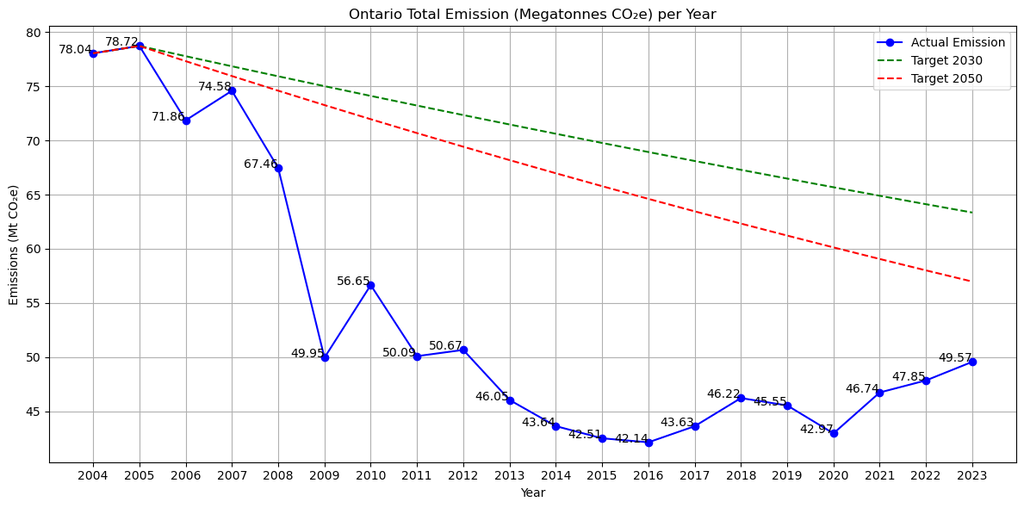

## Ontario GHG Emissions: Progress vs Targets!

- This chart illustrates Ontario’s greenhouse gas (GHG) emissions from 2004 to 2023, measured in megatonnes (Mt CO₂e),  
  alongside projected reduction targets for 2030 and 2050.

## Benchmarking Ontario’s Emissions: How Does It Stack Up?

Ontario has set a target to reduce its emissions by **30% below 2005 levels by 2030**, which would bring total emissions down to around **55.1 megatonnes (Mt)**. Given Ontario’s population of about **16.18 million**, that works out to approximately **3.4 tonnes of CO₂e per person**.

While this is a significant improvement, it still falls short when compared to two key climate benchmarks:

### 🇨🇦 Canada's National Targets (Net-Zero Emissions Accountability Act)

- **40–45% reduction** below 2005 levels by 2030
- **45–50% by 2035**  
  These federal targets would require Ontario to aim for a **2030 emission range of 43–47 Mt** to stay aligned.

### 🌍 The Paris Agreement

- Targets roughly **2 tonnes of CO₂e per person** by 2030  
  To meet that benchmark, Ontario’s total emissions would need to drop closer to **32 Mt** by 2030.

### Looking Ahead to 2050

Ontario’s long-term target for 2050 is **15.74 Mt**, which equals about **1 tonne per person**. That’s a steep decline — but still **not quite enough** to meet a true **net-zero pathway** as defined by global climate goals.

### What Would Real Alignment Look Like?

To truly align with Canada’s federal targets or the Paris Agreement, Ontario would need to:

- Cut 2030 emissions more aggressively, aiming for:
  - **43–47 Mt** (in line with federal goals)
  - **32 Mt** (to match the Paris per capita target)
- Continue reducing steadily toward **net-zero before 2050**, rather than stopping at 15.74 Mt

This comparison makes it clear: Ontario’s current path is a step forward, but **not yet fully aligned** with Canada’s national strategy or the global climate commitment under Paris.

**Click to view full code for Emission Trends By Top Five NAICS Classification**

```
naics_sector_map = {
    #–– Manufacturing (31-33) ––––––––––––––––––––––––––––––––––––––––––––––
    'All Other Basic Inorganic Chemical Manufacturing': '31-33',
    'Automobile and Light-Duty Motor Vehicle Manufacturing': '31-33',
    'Cement Manufacturing': '31-33',
    'Chemical Fertilizer (except Potash) Manufacturing': '31-33',
    'Chemical Pulp Mills': '31-33',
    'Glass Manufacturing': '31-33',
    'Iron and Steel Mills and Ferro-Alloy Manufacturing': '31-33',
    'Lime Manufacturing': '31-33',
    'Motor Vehicle Steering and Suspension Components (except Spring) Manufacturing': '31-33',
    'Newsprint Mills': '31-33',
    'Non-Ferrous Metal (except Aluminum) Smelting and Refining': '31-33',
    'Other Basic Organic Chemical Manufacturing': '31-33',
    'Other Petroleum and Coal Products Manufacturing': '31-33',
    'Paper (except Newsprint) Mills': '31-33',
    'Petrochemical Manufacturing': '31-33',
    'Petroleum Refineries': '31-33',
    'Resin and Synthetic Rubber Manufacturing': '31-33',
    'Wet Corn Milling': '31-33',
    'Aerospace Product and Parts Manufacturing': '31-33',
    'Distilleries': '31-33',
    'Motor Vehicle Metal Stamping': '31-33',
    'Industrial Gas Manufacturing': '31-33',
    'Steel Foundries': '31-33',
    'All Other Miscellaneous Chemical Product Manufacturing': '31-33',
    'All Other Miscellaneous Manufacturing': '31-33',
    'Non-Ferrous Foundries (except Die-Casting)': '31-33',
    'All Other Non-Metallic Mineral Product Manufacturing': '31-33',
    'Artificial and Synthetic Fibres and Filaments Manufacturing': '31-33',
    'Fruit and Vegetable Canning, Pickling and Drying': '31-33',
    'Gypsum Product Manufacturing': '31-33',
    'Office Furniture (except Wood) Manufacturing': '31-33',
    'Oilseed Processing': '31-33',
    'Paperboard Mills': '31-33',
    'Particle Board and Fibreboard Mills': '31-33',
    'Sugar Manufacturing': '31-33',
    'Frozen Food Manufacturing': '31-33',
    'Iron and Steel Pipes and Tubes Manufacturing from Purchased Steel': '31-33',
    'Pharmaceutical and Medicine Manufacturing': '31-33',
    'Wood Office Furniture, including Custom Architectural Woodwork, Manufacturing': '31-33',
    'Clay Building Material and Refractory Manufacturing': '31-33',
    'Institutional Furniture Manufacturing': '31-33',
    'Non-Ferrous Die-Casting Foundries': '31-33',
    'All Other Converted Paper Product Manufacturing': '31-33',
    'Aluminum Rolling, Drawing, Extruding and Alloying': '31-33',
    'Animal (except Poultry) Slaughtering': '31-33',
    'Asphalt Shingle and Coating Material Manufacturing': '31-33',
    'Breweries': '31-33',
    'Butter, Cheese, and Dry and Condensed Dairy Products Manufacturing': '31-33',
    'Chocolate and chocolate confectionery manufacturing from cacao beans': '31-33',
    'Coating, Engraving, Heat Treating and Allied Activities': '31-33',
    'Copper Rolling, Drawing, Extruding and Alloying': '31-33',
    'Fibre, Yarn and Thread Mills': '31-33',
    'Forging': '31-33',
    'Hardwood Veneer and Plywood Mills': '31-33',
    'Motor Vehicle Transmission and Power Train Parts Manufacturing': '31-33',
    'Non-Ferrous Metal (except Copper and Aluminum) Rolling, Drawing, Extruding and Alloying': '31-33',
    'Other Motor Vehicle Parts Manufacturing': '31-33',
    'Other Snack Food Manufacturing': '31-33',
    'Paper Bag and Coated and Treated Paper Manufacturing': '31-33',
    'Polystyrene Foam Product Manufacturing': '31-33',
    'Poultry Processing': '31-33',
    'Rendering and Meat Processing from Carcasses': '31-33',
    'Rice Milling and Malt Manufacturing': '31-33',
    'Spring (Heavy Gauge) Manufacturing': '31-33',
    'Steel Wire Drawing': '31-33',
    'Tire Manufacturing': '31-33',
    'Unsupported Plastic Film and Sheet Manufacturing': '31-33',
    'Waferboard Mills': '31-33',
    'Cold-Rolled Steel Shape Manufacturing': '31-33',
    'Sawmills (except Shingle and Shake Mills)': '31-33',
    'Cookie and Cracker Manufacturing': '31-33',
    'Flavouring Syrup and Concentrate Manufacturing': '31-33',
    'Material Handling Equipment Manufacturing': '31-33',
    'Non-Chocolate Confectionery Manufacturing': '31-33',
    'Sanitary Paper Product Manufacturing': '31-33',
    'Asphalt Paving Mixture and Block Manufacturing': '31-33',
    'Breakfast Cereal Manufacturing': '31-33',
    'Commercial Bakeries and Frozen Bakery Product Manufacturing': '31-33',
    'Soft Drink and Ice Manufacturing': '31-33',
    'Machine Shops': '31-33',
    'Communication and Energy Wire and Cable Manufacturing': '31-33',
    'Beef cattle slaughtering': '31-33',
    'Hog slaughtering': '31-33',

    #–– Mining, Quarrying, and Oil & Gas Extraction (21) ––––––––––––––––––
    'Conventional Oil and Gas Extraction': '21',
    'Gold and Silver Ore Mining': '21',
    'Salt Mining': '21',
    'All Other Metal Ore Mining': '21',
    'Oil and gas extraction (except oil sands)': '21',
    'Copper-Zinc Ore Mining': '21',
    'Diamond Mining': '21',
    'Nickel-Copper Ore Mining': '21',
    'Shale, Clay and Refractory Mineral Mining and Quarrying': '21',
    'All Other Non-Metallic Mineral Mining and Quarrying': '21',

    #–– Utilities (22) –––––––––––––––––––––––––––––––––––––––––––––––––––––
    'Fossil-Fuel Electric Power Generation': '22',
    'Nuclear Electric Power Generation': '22',
    'Other Electric Power Generation': '22',
    'Natural Gas Distribution': '22',
    'Steam and Air-Conditioning Supply': '22',
    'Electric Bulk Power Transmission and Control': '22',
    'Sewage Treatment Facilities': '22',

    #–– Construction (23) –– (none in this list) –––––––––––––––––––––––––––

    #–– Wholesale Trade (41) –––––––––––––––––––––––––––––––––––––––––––––––
    'Petroleum Product Wholesaler-Distributors': '41',

    #–– Retail Trade (44-45) –––––––––––––––––––––––––––––––––––––––––––––––
    'Furniture retailers': '44-45',

    #–– Transportation & Warehousing (48-49) ––––––––––––––––––––––––––––––
    'Pipeline Transportation of Natural Gas': '48-49',
    'Other Support Activities for Air Transportation': '48-49',

    #–– Information & Cultural Industries (51) –– (none) ––––––––––––––––––

    #–– Finance & Insurance (52) –– (none) ––––––––––––––––––––––––––––––––

    #–– Real Estate & Rental & Leasing (53) –– (none) ––––––––––––––––––––––

    #–– Professional, Scientific & Technical Services (54) ––––––––––––––––
    'All Other Professional, Scientific and Technical Services': '54',

    #–– Management of Companies (55) –– (none) ––––––––––––––––––––––––––––

    #–– Administrative & Support / Waste Management & Remediation (56) ––––
    'Waste Treatment and Disposal': '56',
    'Waste Collection': '56',
    'All Other Waste Management Services': '56',

    #–– Educational Services (61) ––––––––––––––––––––––––––––––––––––––––––
    'Universities': '61',
    'Community Colleges and C.E.G.E.P.s': '61',

    #–– Health Care & Social Assistance (62) –––––––––––––––––––––––––––––––
    'General (except Paediatric) Hospitals': '62',
    'Paediatric Hospitals': '62',

    #–– Arts, Entertainment & Recreation (71) –– (none) ––––––––––––––––––––

    #–– Accommodation & Food Services (72) ––––––––––––––––––––––––––––––––
    'Casino Hotels': '72',

    #–– Other Services (except Public Administration) (81) ––––––––––––––––
    'Dry Cleaning and Laundry Services (except Coin-Operated)': '81',

    #–– Public Administration (91) ––––––––––––––––––––––––––––––––––––––––
    'Other Federal Government Public Administration': '91',
    'Defence Services': '91'
}

naics_description_map = {
    '11': 'Agriculture, forestry, fishing and hunting',
    '21': 'Mining, quarrying, and oil and gas extraction',
    '22': 'Utilities',
    '23': 'Construction',
    '31-33': 'Manufacturing',
    '41': 'Wholesale trade',
    '44-45': 'Retail trade',
    '48-49': 'Transportation and warehousing',
    '51': 'Information and cultural industries',
    '52': 'Finance and insurance',
    '53': 'Real estate and rental and leasing',
    '54': 'Professional, scientific and technical services',
    '55': 'Management of companies and enterprises',
    '56': 'Administrative and support, waste management and remediation services',
    '61': 'Educational services',
    '62': 'Health care and social assistance',
    '71': 'Arts, entertainment and recreation',
    '72': 'Accommodation and food services',
    '81': 'Other services (except public administration)',
    '91': 'Public administration'
}
grouped_ontario_facility['NAICS_Sector'] = grouped_ontario_facility['Facility Description'].map(naics_sector_map)
# Map description using the sector code
grouped_ontario_facility['NAICS_Description'] = grouped_ontario_facility['NAICS_Sector'].map(naics_description_map)


from sklearn.preprocessing import MinMaxScaler
import matplotlib.ticker as ticker

# Step 1: Group data
grouped = grouped_ontario_facility.groupby(
    ['Reference Year', 'NAICS_Description', 'NAICS_Sector']
).agg(**{'Total Emission': ('Total Facility Emission (tonnes CO2e)', 'sum')}).reset_index()

# Step 2: Normalize per year (optional: you can normalize per sector too depending on intent)
scaler = MinMaxScaler()
grouped['Normalized Total Emission'] = scaler.fit_transform(grouped[['Total Emission']])

# Step 3: Group top 5 Gas emitters
top_emmiters = grouped.groupby('NAICS_Description')['Normalized Total Emission'].sum()
top_five = top_emmiters.sort_values(ascending=False).head(5).index
top_fives_gas_emitters = grouped[grouped['NAICS_Description'].isin(top_five)]

# Step 4: Pick a clear and diverse color palette
palette = sns.color_palette("Dark2", n_colors=top_fives_gas_emitters['NAICS_Sector'].nunique())

# Step 5: Plot
plt.figure(figsize=(14, 8))
sns.lineplot(
    data=top_fives_gas_emitters,
    x='Reference Year',
    y='Normalized Total Emission',
    hue='NAICS_Description',
    marker='o',
    palette=palette  # <- apply the custom palette here
)

plt.title('Emission Trends By Top Five NAICS Description (2004–2023)', fontsize=14)
plt.ylabel('Normalized Total Emission')
plt.xlabel('Year')
plt.grid(True)
plt.xticks(rotation=45)
plt.gca().xaxis.set_major_locator(ticker.MultipleLocator(1))

plt.legend(title='NAICS Description', bbox_to_anchor=(1.05, 1), loc='upper left')
plt.tight_layout()
plt.show()
```

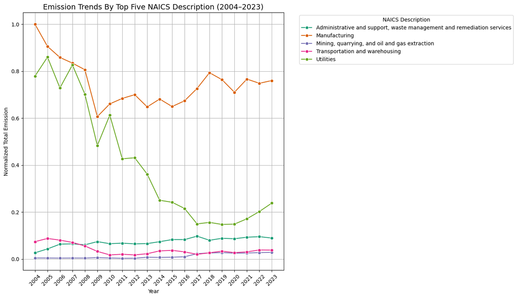

## Emission Trends by Top Five NAICS Sectors (2004–2023)

To deepen the analysis from the previous section, the dataset was further refined in three key ways:

1. **Normalization**: Total facility-level emissions were normalized to a common scale (0–1) to allow for fair comparison across sectors regardless of absolute magnitude.
2. **Sector Classification**: Facility descriptions were mapped to their corresponding **NAICS economic sectors**, ensuring a consistent and industry-recognized classification.
3. **Top 5 Emitters Selection**: The five sectors with the highest cumulative emissions over the 20-year period were identified and isolated for focused analysis.

The resulting line chart visualizes normalized emission trends for these top five sectors from 2004 to 2023.

### Key Insights:

This chart not only confirms the dominant role of traditional industrial sectors in Ontario’s emissions, but also highlights **positive momentum** in energy transformation (e.g., Utilities) and **emerging risks** in support and logistics industries.

Together with earlier benchmarking against 2030 and 2050 targets, this breakdown provides a **sector-specific lens** for identifying high-impact opportunities for intervention and future-proofing Ontario’s decarbonization strategy.

**Click to view full code for the break down emissions by sectors**

```
# Group Ontario emission by Reference Year and Facility Description, then sum the total emission
grouped_ontario_facility = (ontario_emission.groupby(['Reference Year', 'Facility Description'])['Total Emissions (tonnes CO2e)']
                            .sum().reset_index()
                            .rename(columns={'Total Emissions (tonnes CO2e)': 'Total Facility Emission (tonnes CO2e)'})
)

# Round total facility emission by 2 decimals
grouped_ontario_facility['Total Facility Emission (tonnes CO2e)'] = grouped_ontario_facility['Total Facility Emission (tonnes CO2e)'].round(2)

# 1) Identify top 10 facilities by total emissions across all years
facility_sums = grouped_ontario_facility.groupby('Facility Description')['Total Facility Emission (tonnes CO2e)'].sum()
top_10_facilities = facility_sums.sort_values(ascending=False).head(10).index

# 2) Filter your DataFrame to those top 10 facilities
df_top10 = grouped_ontario_facility[grouped_ontario_facility['Facility Description'].isin(top_10_facilities)]

# 3) Pivot: rows = Facility, columns = Year, values = Emissions
emission_pivot = df_top10.pivot(
    index='Facility Description',
    columns='Reference Year',
    values='Total Facility Emission (tonnes CO2e)'
).fillna(0)


# 4) Create the heatmap with Seaborn
plt.figure(figsize=(12, 6))

ax = sns.heatmap(
    emission_pivot / 1e6,  # Convert to Megatonnes (Mt)
    cmap='RdYlGn_r',  # Green (low) to red (high)
    linecolor='white',
    linewidths=0.5,   # Thinner or thicker lines as desired
    cbar_kws={'label': 'CO2e Emission (Megatonnes (Mt CO₂e))'},  # Colorbar label
    annot=False,      # Change to True if you want numeric labels on each cell
    fmt='.2f'
)

# Optional: Rotate x-axis tick labels for clarity
plt.xticks(rotation=90)

plt.title('Ontario Top 10 GHG Emission Facilities')
plt.xlabel('Reference Year')
plt.ylabel('Facility Description')
plt.tight_layout()
plt.show()
```

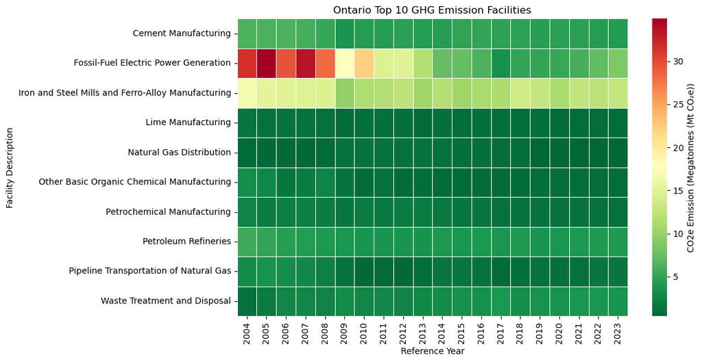

# Sector Analysis: Identifying Ontario’s Top Emitting Facilities

To uncover the largest contributors to Ontario’s total emissions, I analyzed facility-level emission data by **top 10 highest-emitting categories**, revealing fossil-fuel electric power generation experienced the most significant decline in emissions, dropping from over 30 Mt CO₂e in 2004 to under 10 Mt after 2014—primarily due to Ontario’s successful coal phase-out. In contrast, iron and steel mills have remained consistently high emitters, with annual emissions ranging from 10 to 14 Mt CO₂e over the past decade, indicating minimal progress and a clear need for cleaner technologies such as green hydrogen direct reduction and electric arc furnaces. Cement manufacturing and petroleum refineries show modest improvements but still contribute significantly to industrial emissions, making them strong candidates for innovations like CO₂ mineralization and small modular reactors. Meanwhile, sectors such as chemical production, natural gas distribution, and waste treatment have maintained relatively low but steady emissions. Overall, the data highlights that while the electricity sector has decarbonized, industrial emissions have plateaued since 2014, emphasizing the urgency to pivot decarbonization efforts toward heavy industry in order for Ontario to align with its 2030 and 2050 climate goals.

## 🔍 Recommendations for Accelerating Ontario’s Path to Carbon Neutrality

Ontario’s emissions profile shows that while early progress—driven largely by the coal phase-out—led to a significant drop in total greenhouse gas (GHG) emissions between 2005 and 2014, the province has since plateaued. Several sectors, including manufacturing, steel, utilities, and cement production, remain high-emitting and require targeted, next-wave interventions. Below are four actionable and innovative recommendations, each supported by global case studies, that could help Ontario realign with Canada’s 2030 and 2050 decarbonization targets.

### 1. **Adopt Green Hydrogen + Electric Arc Furnace (EAF) Steelmaking**

Traditional steel production in Ontario relies heavily on coal-based blast furnaces. A promising alternative is green hydrogen-based **Direct Reduced Iron (DRI)** combined with Electric Arc Furnaces (EAF). The **HYBRIT** initiative in Sweden—backed by SSAB, LKAB, and Vattenfall—produced the world’s first fossil-free steel and reported potential emissions reductions of up to **90%** compared to conventional steelmaking.  
📌 *Ontario Fit*: Facilities in Hamilton or Sault Ste. Marie (e.g., Algoma Steel) are ideal for pilot deployment due to proximity to clean electricity and industrial infrastructure.

🔗 [HYBRIT Official Project](https://www.hybritdevelopment.com/)  
🔗 [SSAB press release: First fossil-free steel delivered](https://www.ssab.com/en/fossil-free-steel)

### 2. **Deploy Small Modular Reactors (SMRs) for Industrial Heat and Grid Firming**

High-temperature processes in chemicals, steel, and oil refining still rely on fossil fuels. **Small Modular Reactors (SMRs)** like those developed by **NuScale Power** provide safe, zero-emission steam and electricity for industrial clusters. NuScale estimates a single SMR module can cut **>95% of CO₂** emissions at sites currently using natural gas for process heat.  
📌 *Ontario Fit*: With its nuclear heritage and skilled workforce, Ontario could deploy SMRs at industrial hubs like Sarnia to decarbonize energy-intensive sectors while supporting hydrogen production.

🔗 [NuScale SMR Technology](https://www.nuscalepower.com/)

### 3. **Blend Green Hydrogen into Ontario’s Natural Gas Grid (Up to 20%)**

Blending renewable hydrogen into existing gas pipelines reduces emissions without requiring appliance upgrades. California’s **SoCalGas**, in collaboration with the University of California, demonstrated that a **20% hydrogen blend** could reduce emissions equivalent to **1 million gasoline vehicles per year**. Germany and the Netherlands have also piloted hydrogen blending in residential gas networks.  
📌 *Ontario Fit*: Enbridge Gas already operates power-to-gas pilot sites in Markham and could scale this across the province to reduce utility-sector emissions, as shown to be rising again in your data.

🔗 [SoCalGas H₂ Blending Pilot](https://www.socalgas.com/sustainability/hydrogen)  
🔗 [Enbridge Power-to-Gas Pilot](https://www.enbridgegas.com/sustainability/clean-heating/hydrogen)  
🔗 [Hydrogen Europe: H₂ blending potential](https://www.h2-view.com/story/portugal-opens-tender-for-hydrogen-blending-in-gas-network/2110596.article/)

### 4. **Scale AI-Based Industrial Digital Twins for Process Optimization**

**Digital twins** create virtual replicas of industrial systems that sync in real-time with physical operations. These systems, as tested by **Siemens** and **NVIDIA**, can reduce energy usage by **15–20%** and increase efficiency by optimizing motor speeds, HVAC, and raw material use. These savings are already being realized in U.S. and German factories.  
📌 *Ontario Fit*: Given the large contribution of manufacturing to provincial emissions (shown in the normalized NAICS chart), Ontario could offer incentives for factories to adopt digital twins—delivering fast reductions without major capital costs.

🔗 [Siemens & NVIDIA Digital Twin Platform](https://press.siemens.com/global/en/pressrelease/siemens-and-nvidia-partner-enable-industrial-metaverse)  
🔗 [NVIDIA: Digital Twins in Manufacturing](https://blogs.nvidia.com/blog/how-digital-twins-scale-industrial-ai/)